# SME Loan Documentation Phase2

Anurag Swain

7 August 2018

## Introduction

Here we will be using the ScoringDataset which contains companies which have all the important core attributes present. The list of companies was obtained from Phase1.The ScoringDataset again contains data which has attributes recurring, with the year appended along with the column name.So the data need to be reformatted again just like in phase1

## 1.Dataset used

The data is read from the ScoringDataset.csv into dataframe ScoringDataset The attributes are recurring with the year appended

#### Need to format data

```r
colnames(ScoringDataset[,1:40])
```

```
##  [1] "Company.Name"
##  [2] "Prowess.company.code"
##  [3] "Entity.type"
##  [4] "ROC.registration.number"
##  [5] "Incorporation.year"
##  [6] "Industry.group"
##  [7] "Industry.type"
##  [8] "Main.product.service.group"
##  [9] "Main.product.service.group.code"
## [10] "NIC.name"
## [11] "NIC.code"
## [12] "Ownership.group"
## [13] "NSE.symbol"
## [14] "BSE.scrip.code"
## [15] "Total.liabilities.2009"
```

[output cut: 25 more lines]

## 2.Data Wrangling

The data from ScoringDataset is then extracted into seperate datasets where the year of the finacial data is dispalyed in a column and stored in a list of dataframes (MajorAttri,CostofGoodsSoldlist,interestexp_otherattri,salesnattri,Ratingsofcompany - all these list have data from 2009-2018 stored in the list with index1-2009 and index10-2018).

1.Firmographics - Details about the firm  
2.MajorAttri_listmerged - Has Balance sheet data (2009-2018):Total liabilities,Total capital…  
3.salesnattri_listmerged -Has Sales data (2009-2018)  
4.interestexp_otherattri_listmeged - Has Expenses data (2009-2018)  
5.CostofGoodsSoldlist_merged - Has cost of goods sold data (2009-2018)  
6.Ratingsofcompany_listmerged - Has Ratings of the company (2009-2018)

```r
colnames(Firmographics)
```

```
##  [1] "Company.Name"                    "Prowess.company.code"
##  [3] "Entity.type"                     "ROC.registration.number"
##  [5] "Incorporation.year"              "Industry.group"
##  [7] "Industry.type"                   "Main.product.service.group"
##  [9] "Main.product.service.group.code" "NIC.name"
## [11] "NIC.code"                        "Ownership.group"
## [13] "NSE.symbol"                      "BSE.scrip.code"
```

```r
colnames(MajorAttri_listmerged)
```

```
##  [1] "Total.liabilities"
##  [2] "Total.capital"
##  [3] "Reserves.and.funds"
##  [4] "Non.current.liabilities"
##  [5] "Current.liabilities...provisions"
##  [6] "Short.term.borrowings"
##  [7] "Short.term.trade.payables.and.acceptances"
##  [8] "Net.worth"
##  [9] "Capital.employed"
## [10] "Contingent.liabilities"
## [11] "Non.current.assets"
## [12] "Gross.fixed.assets"
## [13] "Net.fixed.assets"
## [14] "Current.assets..incl..short.term.investments..loans...advances."
## [15] "Cash.balance"
## [16] "Short.term.trade.receivables...bills.receivable"
## [17] "Short.term.inventories"
## [18] "Year"
## [19] "CompanyNames"
```

```r
summary(CostofGoodsSoldlist[[1]])
```

```
##  CostofGoodsSold          Year
##  Min.   :   -181.8   Min.   :2009
##  1st Qu.:      4.6   1st Qu.:2009
##  Median :    200.3   Median :2009
##  Mean   :   2807.9   Mean   :2009
##  3rd Qu.:    943.6   3rd Qu.:2009
##  Max.   :2835888.0   Max.   :2009
##  NA's   :4771
##                            CompanyNames
##  24/7 Customer Pvt. Ltd.         :    1
##  3 F Industries Ltd.             :    1
##  3D P L M Software Solutions Ltd.:    1
##  3D Technopack Pvt. Ltd.         :    1
##  3I Infotech Ltd.                :    1
##  3M India Ltd.                   :    1
##  (Other)                         :10388
```

```r
summary(CostofGoodsSoldlist[[2]])
```

```
##  CostofGoodsSold          Year
##  Min.   :  -1986.5   Min.   :2010
##  1st Qu.:      5.6   1st Qu.:2010
##  Median :    219.3   Median :2010
##  Mean   :   2822.2   Mean   :2010
##  3rd Qu.:   1031.4   3rd Qu.:2010
##  Max.   :2434237.6   Max.   :2010
##  NA's   :4561
##                            CompanyNames
##  24/7 Customer Pvt. Ltd.         :    1
##  3 F Industries Ltd.             :    1
##  3D P L M Software Solutions Ltd.:    1
##  3D Technopack Pvt. Ltd.         :    1
##  3I Infotech Ltd.                :    1
##  3M India Ltd.                   :    1
##  (Other)                         :10388
```

```r
colnames(CostofGoodsSoldlist_merged)
```

```
## [1] "CostofGoodsSold" "Year"            "CompanyNames"
```

```r
colnames(interestexp_otherattri_listmeged)
```

```
## [1] "Interest.expense"
## [2] "Premium.discount.on.issue.of.debt.instruments"
## [3] "Other.fund.based.financial.services.expenses"
## [4] "Treasury.operations.expenses"
## [5] "Fund.based.financial.services.expenses"
## [6] "Fee.based.financial.services.expenses"
## [7] "Year"
## [8] "CompanyNames"
```

```r
colnames(salesnattri_listmerged)
```

```
## [1] "Sales"
## [2] "Other.income"
## [3] "Total.expenses"
## [4] "PBDITA"
## [5] "PBT"
## [6] "Cash.profit"
## [7] "Profit.after.tax.reported.by.company"
## [8] "Year"
## [9] "CompanyNames"
```

All these seperate data sets were then merged to create a Merged_Masterdata, which has all the attributes present

```r
dim(Merged_Masterdata)
```

```
## [1] 103940     49
```

```r
colnames(Merged_Masterdata)
```

```
##  [1] "Company.Name"
##  [2] "Prowess.company.code"
##  [3] "Entity.type"
##  [4] "ROC.registration.number"
##  [5] "Incorporation.year"
##  [6] "Industry.group"
##  [7] "Industry.type"
##  [8] "Main.product.service.group"
##  [9] "Main.product.service.group.code"
## [10] "NIC.name"
## [11] "NIC.code"
## [12] "Ownership.group"
## [13] "NSE.symbol"
## [14] "BSE.scrip.code"
## [15] "Year"
```

[output cut: 34 more lines]

## 3.Creating a Dataset where default companies to non-default are propotionate

We now have the same company occuring multiple time corresponding to the year of its financial data.So we need to pick a particular year for a particular company.We will use the code from SubsetScoringDataset.R to obtain the Final_dataset(For companies that has defaulted, ie where the default flag is set to 1, we select the financials of the previous year, and for non-default companies the records corresponding to its latest financial year was chosen )

```r
dim(Final_dataset)
```

```
## [1] 9545   49
```

```r
colnames(Final_dataset)
```

```
##  [1] "Company.Name"
##  [2] "Prowess.company.code"
##  [3] "Entity.type"
##  [4] "ROC.registration.number"
##  [5] "Incorporation.year"
##  [6] "Industry.group"
##  [7] "Industry.type"
##  [8] "Main.product.service.group"
##  [9] "Main.product.service.group.code"
## [10] "NIC.name"
## [11] "NIC.code"
## [12] "Ownership.group"
## [13] "NSE.symbol"
## [14] "BSE.scrip.code"
## [15] "Year"
```

[output cut: 34 more lines]

#### Before imputing

Missing values

```r
summary(Final_dataset$Total.liabilities)
```

```
##      Min.   1st Qu.    Median      Mean   3rd Qu.      Max.      NA's
##       0.0     455.7    1339.3    9538.5    4586.6 2354990.8      2771
```

```r
summary(Final_dataset$Total.expenses)
```

```
##    Min. 1st Qu.  Median    Mean 3rd Qu.    Max.    NA's
##   -1308     448    1293    7663    3881 4797259    2924
```

## 4.Data Cleaning and imputation

In script Clean_Final_dataset.R , we will impute the missing attributes with mean-imputation based on Industry.group(more specific grouping) and then on basis of Entity.type (generalised grouping). And we use the script NewVariables.R to create the derived attributes.

#### After imputing

```r
summary(Final_dataset_meanimpute$Total.liabilities)
```

```
##      Min.   1st Qu.    Median      Mean   3rd Qu.      Max.
##       0.0     720.6    2737.9    9173.9    6484.4 2354990.8
```

```r
summary(Final_dataset_meanimpute$Total.expenses)
```

```
##    Min. 1st Qu.  Median    Mean 3rd Qu.    Max.
##   -1308     745    2242    7190    5547 4797259
```

#### Derived Attributes added

```r
colnames(Final_dataset_meanimpute)
```

```
##  [1] "Company.Name"
##  [2] "Prowess.company.code"
##  [3] "Entity.type"
##  [4] "ROC.registration.number"
##  [5] "Incorporation.year"
##  [6] "Industry.group"
##  [7] "Industry.type"
##  [8] "Main.product.service.group"
##  [9] "Main.product.service.group.code"
## [10] "NIC.name"
## [11] "NIC.code"
## [12] "Ownership.group"
## [13] "NSE.symbol"
## [14] "BSE.scrip.code"
## [15] "Year"
```

[output cut: 54 more lines]

## 5.Outlier treatment and Capping

In script Outlierdetection.R ,we have capped values below 5 quantile (5%) and above 95 quantile (95%).

#### Before capping Current Ratio

```r
library(ggplot2)
library(scales)

summary(Final_dataset_bkup$CurrentRatio)
```

```
##    Min. 1st Qu.  Median    Mean 3rd Qu.    Max.
##  0.4969  1.0772  1.2980  3.9256  1.7986 33.7890
```

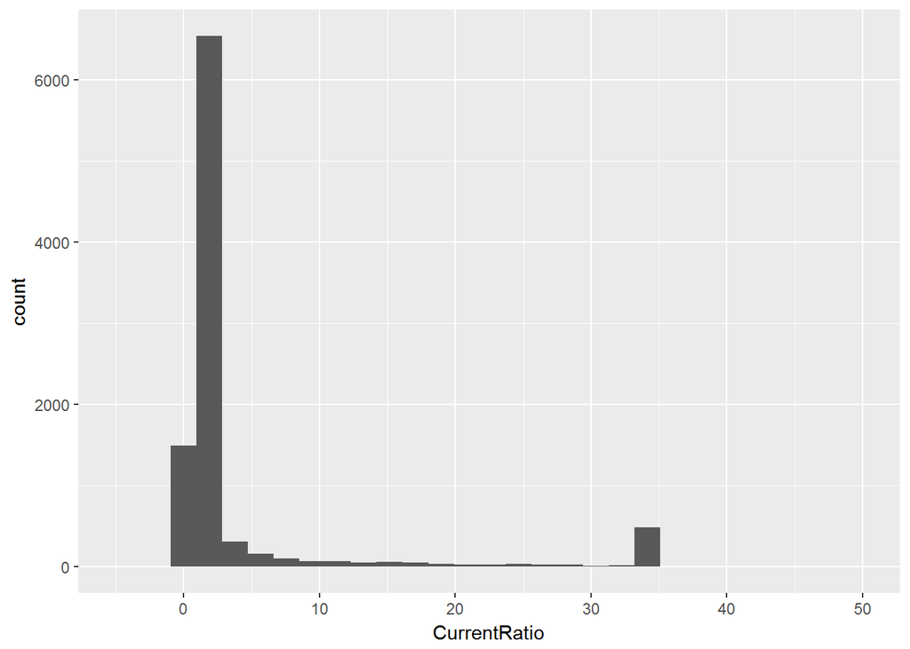

```r
ggplot(Final_dataset_bkup,aes(CurrentRatio))+geom_histogram(bins = 30)+scale_x_continuous(limits = c(-5,50))
```

#### After capping Current Ratio

```r
library(ggplot2)
library(scales)

summary(Final_dataset_capped_5to95perc$CurrentRatio)
```

```
##    Min. 1st Qu.  Median    Mean 3rd Qu.    Max.
##  0.4969  1.0772  1.2980  3.9256  1.7986 33.7890
```

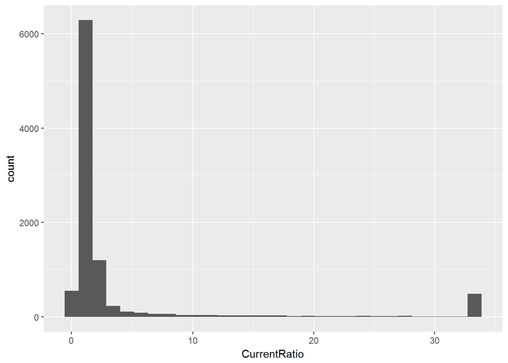

```r
ggplot(Final_dataset_capped_5to95perc,aes(CurrentRatio))+geom_histogram(bins=30)
```

### Before capping Inventory Days

```r
library(ggplot2)
library(scales)

summary(Final_dataset_bkup$InventoryDays)
```

```
##    Min. 1st Qu.  Median    Mean 3rd Qu.    Max.
##    4.54   54.06  155.68     Inf 1072.75     Inf
```

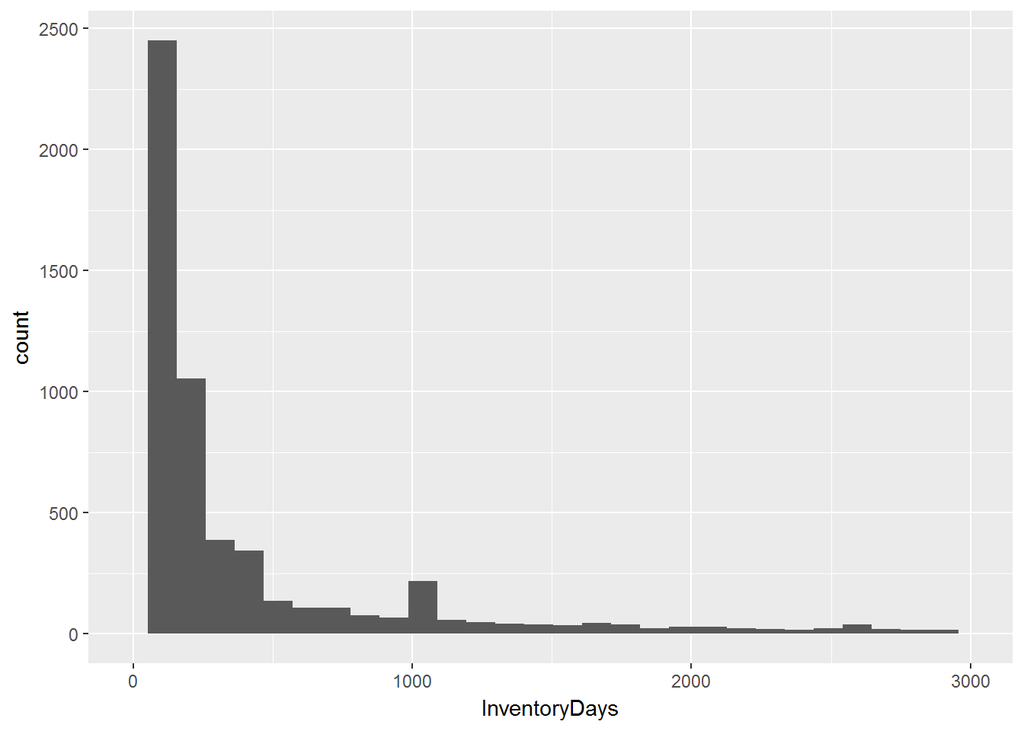

```r
ggplot(Final_dataset_bkup,aes(InventoryDays))+geom_histogram(bins = 30)+scale_x_continuous(limits = c(-10,3000))
```

### After capping Inventory Days

```r
library(ggplot2)
library(scales)

summary(Final_dataset_capped_5to95perc$InventoryDays)
```

```
##     Min.  1st Qu.   Median     Mean  3rd Qu.     Max.
##    4.809   38.558   71.013  214.484  129.781 1639.014
```

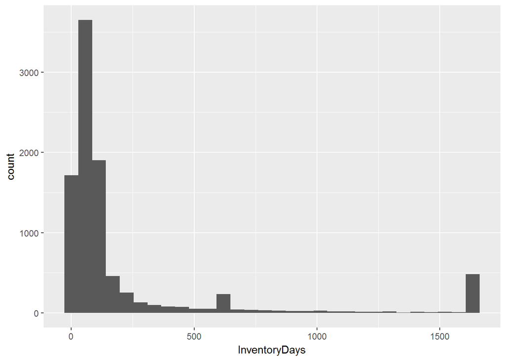

```r
ggplot(Final_dataset_capped_5to95perc,aes(InventoryDays))+geom_histogram(bins=30)
```

### Before capping Payable Days

```r
library(ggplot2)
library(scales)

summary(Final_dataset_bkup$PayableDays)
```

```
##    Min. 1st Qu.  Median    Mean 3rd Qu.    Max.
##   3.395  42.940 118.237     Inf 563.894     Inf
```

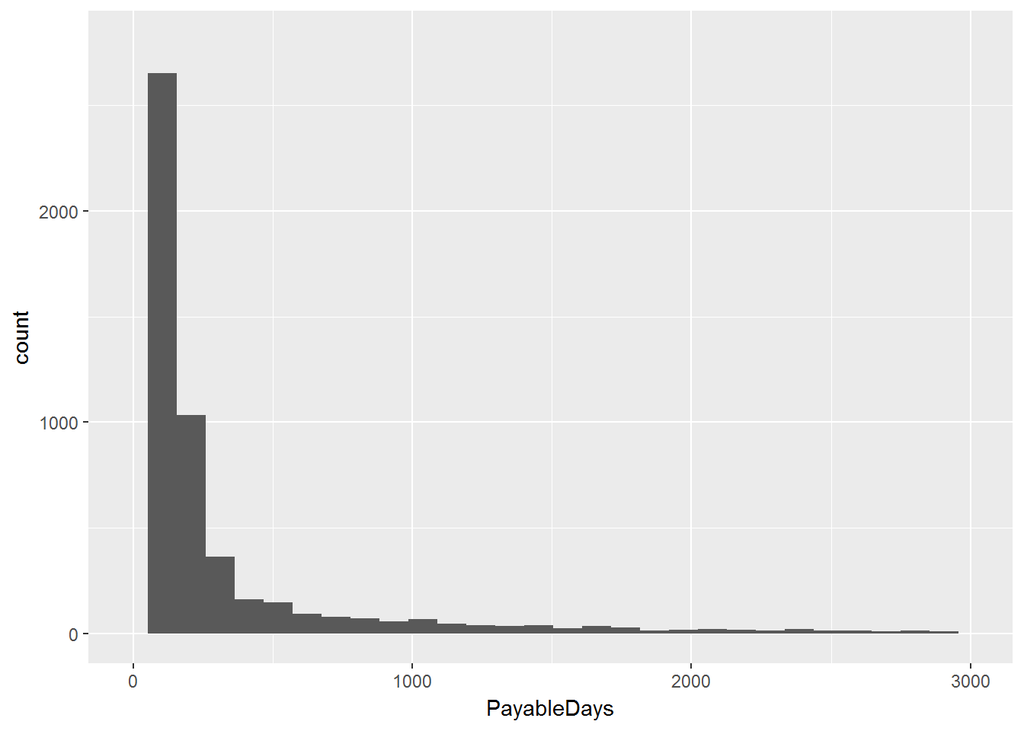

```r
ggplot(Final_dataset_bkup,aes(PayableDays))+geom_histogram(bins = 30)+scale_x_continuous(limits = c(-10,3000))
```

### After capping Payable Days

```r
library(ggplot2)
library(scales)

summary(Final_dataset_capped_5to95perc$PayableDays)
```

```
##    Min. 1st Qu.  Median    Mean 3rd Qu.    Max.
##   5.723  31.774  58.299 115.883  98.722 770.776
```

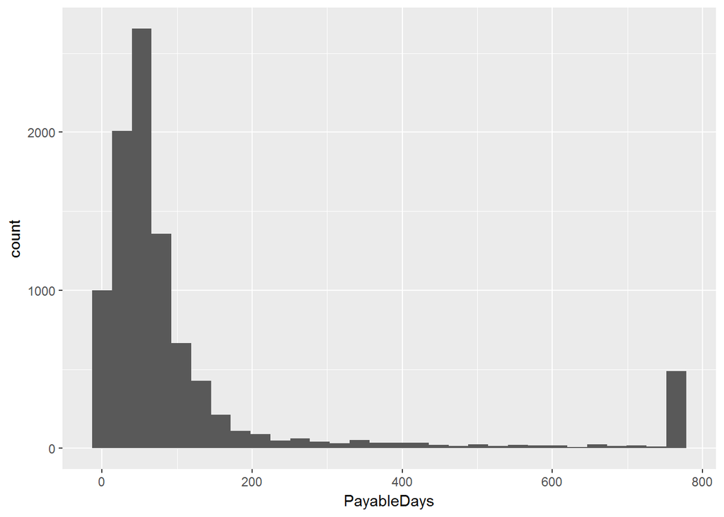

```r
ggplot(Final_dataset_capped_5to95perc,aes(PayableDays))+geom_histogram(bins = 30)
```

Before and after capping summary for derived attributes Final_dataset_bkup has before capping data and Final_dataset_capped_5to95perc has after capping data

```r
summary(Final_dataset_bkup$InventoryDays)
```

```
##    Min. 1st Qu.  Median    Mean 3rd Qu.    Max.
##    4.54   54.06  155.68     Inf 1072.75     Inf
```

```r
summary(Final_dataset_capped_5to95perc$InventoryDays)
```

```
##     Min.  1st Qu.   Median     Mean  3rd Qu.     Max.
##    4.809   38.558   71.013  214.484  129.781 1639.014
```

```r
summary(Final_dataset_bkup$ReceivableDays)
```

```
##    Min. 1st Qu.  Median    Mean 3rd Qu.    Max.
##   8.909  43.246  75.614 141.910 124.776 902.582
```

```r
summary(Final_dataset_capped_5to95perc$ReceivableDays)
```

```
##    Min. 1st Qu.  Median    Mean 3rd Qu.    Max.
##   8.909  43.246  75.614 141.910 124.776 902.582
```

```r
summary(Final_dataset_bkup$PayableDays)
```

```
##    Min. 1st Qu.  Median    Mean 3rd Qu.    Max.
##   3.395  42.940 118.237     Inf 563.894     Inf
```

```r
summary(Final_dataset_capped_5to95perc$PayableDays)
```

```
##    Min. 1st Qu.  Median    Mean 3rd Qu.    Max.
##   5.723  31.774  58.299 115.883  98.722 770.776
```

For Age of the comapny, we have imputed first on basis of industry.group and then on basis of entity.type

Comapnies with missing AgeofCompany have been imputed with the following values

```r
head(MissingAge_df,10)
```

```
##                           Industry.group  missage
## 1                              Abrasives 51.50000
## 2                 Agricultural machinery 20.00000
## 3       Air-conditioners & refrigerators 29.50000
## 4  Air transport infrastructure services 13.25000
## 5                 Air transport services 19.38095
## 6         Aluminium & aluminium products 27.10909
## 7             Animation content provider 19.50000
## 8                        Bakery products 20.46154
## 9                         Beer & alcohol 30.47727
## 10                    Boilers & turbines 23.72000
```

```r
head(MissingAge_dfbyentity,10)
```

```
##                Entity.type missage_entity
## 1 Associations/Federations       54.75000
## 2            Co-operatives       44.50000
## 3         Foreign Entities       12.00000
## 4              Governments       29.50000
## 5        Partnership firms       13.37912
## 6             Private Ltd.       19.23989
## 7              Public Ltd.       28.39743
## 8                   Trusts       21.10684
## 9    Unlimited Liabilities       20.75000
```

## 6.Data Normalisation

Here we used min-max normalisation to normalise the data to between 0 and 1

Sharing normalisations for a few attributes

#### Before Normalising payable days

```r
library(ggplot2)
library(scales)

summary(Final_dataset_capped_5to95perc$PayableDays)
```

```
##    Min. 1st Qu.  Median    Mean 3rd Qu.    Max.
##   5.723  31.774  58.299 115.883  98.722 770.776
```

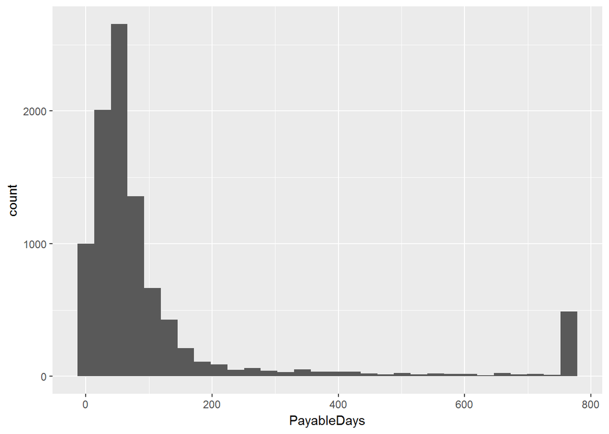

```r
ggplot(Final_dataset_capped_5to95perc,aes(PayableDays))+geom_histogram(bins = 30)
```

#### After Normalising payable days

```r
library(ggplot2)
library(scales)

summary(Final_dataset_Norm_5to95$PayableDays)
```

```
##    Min. 1st Qu.  Median    Mean 3rd Qu.    Max.
## 0.00000 0.03405 0.06872 0.14400 0.12159 1.00000
```

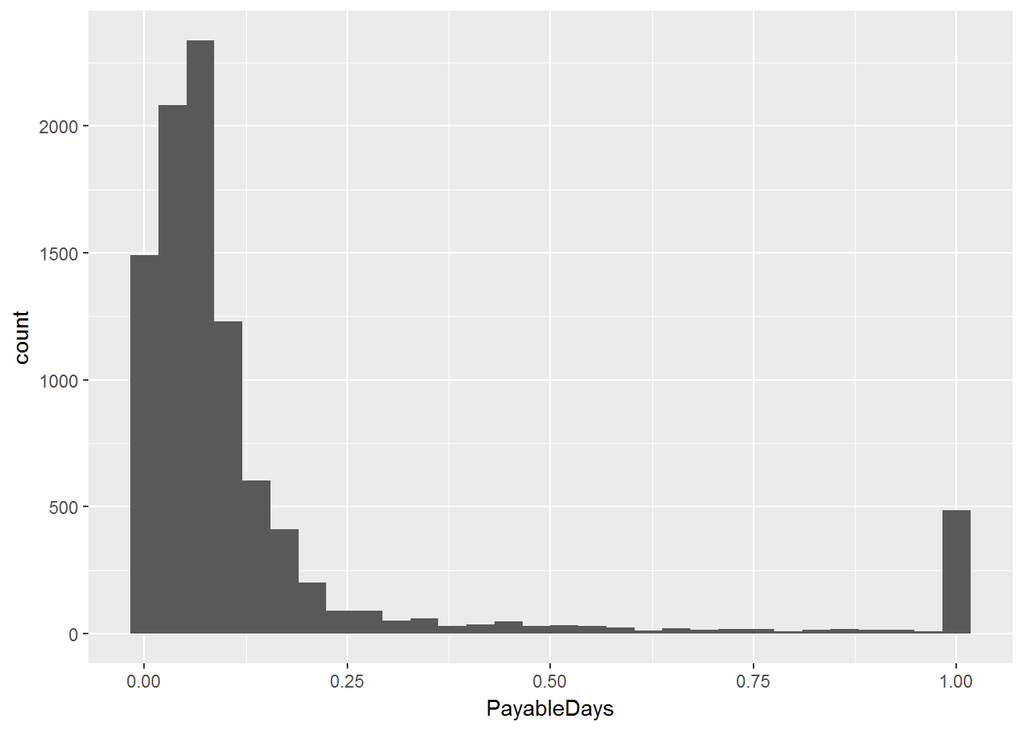

```r
ggplot(Final_dataset_Norm_5to95,aes(PayableDays))+geom_histogram(bins=30)
```

#### Before Normalising interest-ratio coverage

```r
library(ggplot2)
library(scales)

summary(Final_dataset_capped_5to95perc$InterestRatioCoverage)
```

```
##     Min.  1st Qu.   Median     Mean  3rd Qu.     Max.     NA's
##  -0.0026   0.7223   3.6009  34.3060  15.1934 390.7484        1
```

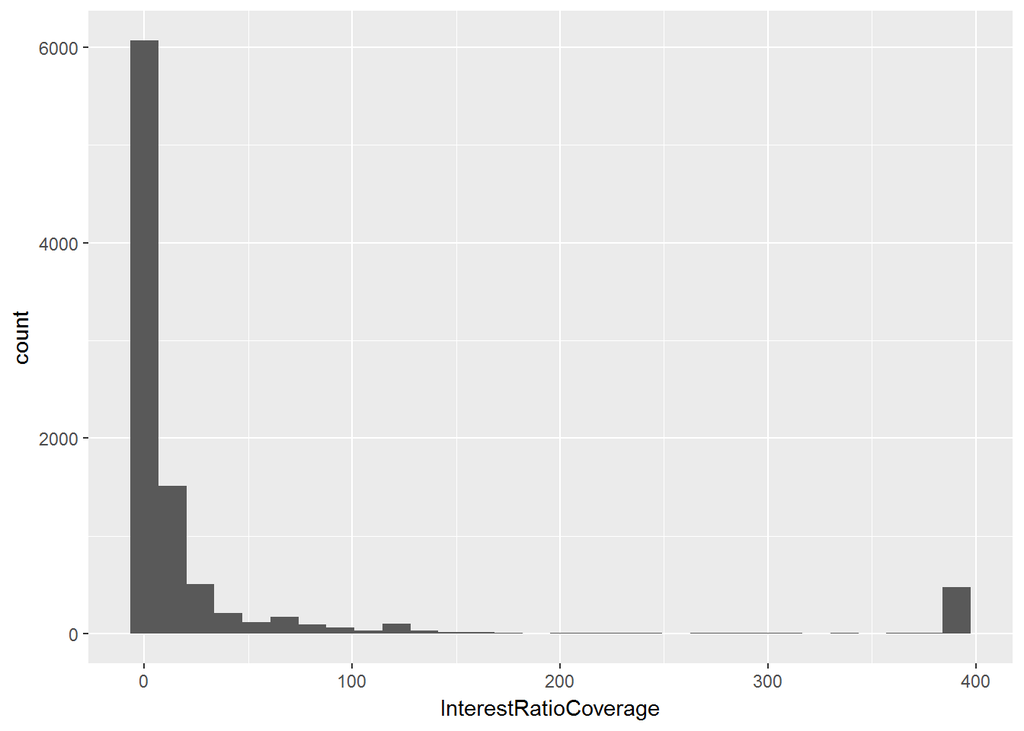

```r
ggplot(Final_dataset_capped_5to95perc,aes(InterestRatioCoverage))+geom_histogram(bins = 30)
```

#### After Normalising interest-ratio coverage

```r
library(ggplot2)
library(scales)

summary(Final_dataset_Norm_5to95$InterestRatioCoverage)
```

```
##     Min.  1st Qu.   Median     Mean  3rd Qu.     Max.
## 0.000000 0.001855 0.009222 0.087802 0.038889 1.000000
```

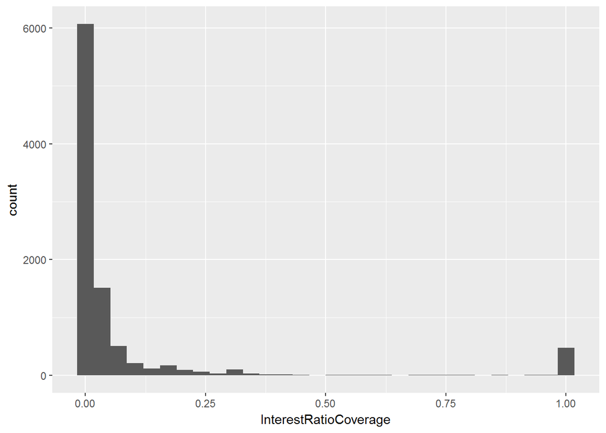

```r
ggplot(Final_dataset_Norm_5to95,aes(InterestRatioCoverage))+geom_histogram(bins=30)
```

## 7.Data modelling using Machine Learning

Used logistic,decision tree and random forest models for machine learning. For decision tree, couldn’t create a tree beyond the root node because of cross-validation error being greater than 100%, due to which it was overfitting.Hence have focussed on the other two models

### Using logistic regression

```r
Model_logistic<-glm(Default.Flag~CurrentRatio+QuickRatio+InterestRatioCoverage+DebtEquityRatio+DSCR+EBITA+PBT_percentage+InventoryDays+ReceivableDays+PayableDays+ROCE+RONW+FixedAssetsTurnover+AgeofCompany+BSE_Flag+EntityTypePublicFlag+EntityTypePrivateFlag+Ownershipgrp_PrivateForeign+Ownershipgrp_PrivateIndian,family=binomial(link='logit'),data = Final_datasetTrain_Norm_5to95)

summary(Model_logistic)
```

```
##
## Call:
## glm(formula = Default.Flag ~ CurrentRatio + QuickRatio + InterestRatioCoverage +
##     DebtEquityRatio + DSCR + EBITA + PBT_percentage + InventoryDays +
##     ReceivableDays + PayableDays + ROCE + RONW + FixedAssetsTurnover +
##     AgeofCompany + BSE_Flag + EntityTypePublicFlag + EntityTypePrivateFlag +
##     Ownershipgrp_PrivateForeign + Ownershipgrp_PrivateIndian,
##     family = binomial(link = "logit"), data = Final_datasetTrain_Norm_5to95)
##
## Deviance Residuals:
##     Min       1Q   Median       3Q      Max
## -1.5347  -0.6952  -0.5716  -0.3686   2.7012
##
## Coefficients:
##                               Estimate Std. Error z value Pr(>|z|)
## (Intercept)                  -13.32132  208.57903  -0.064 0.949076
## CurrentRatio                  -0.16860    0.52023  -0.324 0.745879
## QuickRatio                     0.28525    0.51516   0.554 0.579781
## InterestRatioCoverage         -0.11498    0.15247  -0.754 0.450761
## DebtEquityRatio               -0.19386    0.17846  -1.086 0.277327
## DSCR                          -0.48451    0.18059  -2.683 0.007297 **
## EBITA                          0.64209    0.16369   3.923 8.76e-05 ***
## PBT_percentage                -1.19508    0.18807  -6.354 2.09e-10 ***
## InventoryDays                 -0.50555    0.22498  -2.247 0.024635 *
## ReceivableDays                 0.20422    0.24100   0.847 0.396766
## PayableDays                    0.05733    0.25964   0.221 0.825226
## ROCE                          -1.30636    0.19699  -6.632 3.32e-11 ***
## RONW                          -0.10301    0.17764  -0.580 0.561986
## FixedAssetsTurnover           -0.02534    0.14645  -0.173 0.862643
## AgeofCompany                  -1.21934    0.35786  -3.407 0.000656 ***
## BSE_Flag1                      0.43764    0.08554   5.116 3.12e-07 ***
## EntityTypePublicFlag1         13.04077  208.57898   0.063 0.950147
## EntityTypePrivateFlag1        12.60473  208.57898   0.060 0.951812
## Ownershipgrp_PrivateForeign1  -0.90612    0.37923  -2.389 0.016878 *
## Ownershipgrp_PrivateIndian1    0.40463    0.08551   4.732 2.22e-06 ***
## ---
## Signif. codes:  0 '***' 0.001 '**' 0.01 '*' 0.05 '.' 0.1 ' ' 1
##
## (Dispersion parameter for binomial family taken to be 1)
##
##     Null deviance: 6534.0  on 6583  degrees of freedom
## Residual deviance: 6151.5  on 6564  degrees of freedom
## AIC: 6191.5
##
## Number of Fisher Scoring iterations: 13
```

```r
PredictedTrain_logistic<-predict(Model_logistic,Final_datasetTrain_Norm_5to95,type = "response")
table(actualvalue=Final_datasetTrain_Norm_5to95$Default.Flag,predictedvalue=PredictedTrain_logistic>0.5)
```

```
##            predictedvalue
## actualvalue FALSE TRUE
##           0  5248   39
##           1  1269   28
```

The training set gives accuracy of about 80%

```r
PredictedTest_logistic<-predict(Model_logistic,Final_datasetTest_Norm_5to95,type = "response")
table(actualvalue=Final_datasetTest_Norm_5to95$Default.Flag,predictedvalue=PredictedTest_logistic>0.5)
```

```
##            predictedvalue
## actualvalue FALSE TRUE
##           0  2327   20
##           1   591   21
```

### Using Randomforest

#### For default mtry

```r
print(bestmtry)
```

```
##       mtry  OOBError
## 2.OOB    2 0.1963852
## 3.OOB    3 0.1971446
## 4.OOB    4 0.1976002
## 6.OOB    6 0.1968408
```

For mtry=4 The Training accuracy was 95% The testing accuracy was 80%

#### On mtry =2

```r
table(actualvalue=Final_datasetTrain_Norm_5to95$Default.Flag,predictedvalue=PredictedTrain_randomforest)
```

```
##            predictedvalue
## actualvalue    0    1
##           0 5276   11
##           1  285 1012
```

```r
table(actualvalue=Final_datasetTest_Norm_5to95$Default.Flag,predictedvalue=PredictedTest_randomforest)
```

```
##            predictedvalue
## actualvalue    0    1
##           0 2316   31
##           1  568   44
```

Testing accuracy : 79.7%